# The shape of things to come

## Topological Data Analysis applied to plant biology

## Erik Amézquita

Dept. of Computational Mathematics, Science & Engineering ([CMSE](https://cmse.msu.edu/))

Michigan State University

February 2022

# Plan

1. Gentle introduction to Topological Data Analysis (TDA)
2. A brief overview of TDA software available
3. Focus on the Euler characteristic to efficiently extract shape from very large images (both 2D and 3D)

# Goal

- Give you a place to start if you want to delve deeper into TDA

# Options to follow along

- Clone the [github repo](https://github.com/amezqui3/ect_and_barley): `https://github.com/amezqui3/ect_and_barley`
- Run directly from [**google collab**](https://colab.research.google.com/github/amezqui3/demeter/blob/main/tutorial/nappn2022_shape_of_things_to_come.ipynb): https://colab.research.google.com/github/amezqui3/demeter/blob/main/tutorial/nappn2022_shape_of_things_to_come.ipynb

# If running from google colab, you might need to load your Drive and add some extra files.

- In your drive, create a folder named `tda_workshop`
- Inside this folder, copy the contents from this other [folder](https://drive.google.com/drive/folders/1h_bIqrpkzwG9z5S5Q9Bs3zscQSrqPMTB?usp=sharing): https://drive.google.com/drive/folders/1h_bIqrpkzwG9z5S5Q9Bs3zscQSrqPMTB?usp=sharing

# Quantify and compare all shape diversity

- Data diversity: morphometrics might not be enough

```python
display.display(widgets.HBox([video1,video2,video3,video4]))
```

```
HBox(children=(Output(), Output(), Output(), Output()))
```

## Traditional Morphometry

[figure not shown]

Credits: [Gupta *et al* (2019)](https://doi.org/10.1111/nph.16286)

## Geometric Morphometrics may not be enough

| **Elliptic Fourier Descriptors (EFD)** Credits: [Chitwood and Sinha (2016)](https://doi.org/10.1016/j.cub.2016.02.033) | **Landmark-based morphometrics (GMM)** Credits: [Chitwood (2020)](https://doi.org/10.1002/ppp3.10157) |
| --- | --- |

# We need something more robust for more diverse data

```python
display.display(widgets.HBox([video5,video6,video7,video8]))
```

```
HBox(children=(Output(), Output(), Output(), Output()))
```

# Topological Data Analysis (TDA)

[figure not shown]

**Raw Data**

- X-ray CT
- Point clouds
- Time series

**Topological Summary**

- Euler Characteristic
- Persistence diagrams
- Mapper/Reeb graphs

**Analysis**

- Statistics
- Machine learning
- Classification/prediction

# Main goal of TDA

Provide

- **Quantifiable**
- **Comparable**
- **Robust**
- **Concise** summaries of the shape of data

## Shape is data, and data is shape

[figure not shown]

Credits: [Daniel Park](https://orcid.org/0000-0003-2783-530X)

# What is topology anyway?

## Topology for non-topologists

- Topology thinks of the world as if made out of **clay**.
- The shape of an object does not change if we stretch it, shrink it or mold it smoothly
- However, breaking, cutting, and pasting however are not smooth operations, and alter the shape of objects.

[figure not shown]

- An *Arabidopsis thaliana* leaf under different smooth transformations

### A coffee mug and a bagel are topologically equivalent

[figure not shown]

Credits: [Wikimedia commons](https://commons.wikimedia.org/wiki/File:Mug_and_Torus_morph.gif)

### A cow and a ball can also be topologically equivalent

- We have to assume that the cow keeps its nostrils, ears, and mouth shut

[figure not shown]

## Some basic language clarifications: hollows do matter

[figure not shown]

**Circle**

[figure not shown]

**Sphere**

- Hollow/empty inside

**Disc**

**Ball**

- Solid inside

# Bringing topology to real-life settings

## Topological Data Analysis

# Two basic ingredients to do TDA

## Data points / Network / Image → Building blocks → Simplices

### Simplices → Complexes

[figure not shown]

**Simplicial complex**

- 3 connected components
- 1 loop
- 1 void

**Cubical complex**

- 2 connected components
- 3 loops
- 1 void
- TDA seeks to describe the **shape** of data based on important **topological features**:
  - Connected components
  - Loops
  - Voids
- Their count is referred to as **Betti numbers**, $\beta_0, \beta_1, \beta_2$.

## Filter function: point / pixel → real number

- A complex is built by adding low-valued simplices first

| **Curvature** | **Eccentricity** | **Gaussian Density** | **Vietoris-Rips** |
| --- | --- | --- | --- |

- TDA seeks to describe how the topological **features** (number of connected components, loops, voids) **change** as we increase the filter values.

## Example 1

### Detect holes → detect cancerous tissue

|  | Credits: [Qaiser *et al.* (2019)](https://doi.org/10.1016/j.media.2019.03.014) |
| --- | --- |

## Example 2

### Detect holes → detect reassortment and horizontal evolution

|  | Credits: [Chan *et al.* (2013)](https://doi.org/10.1073/pnas.1313480110) |
| --- | --- |

## Example 3

### Detect holes → detect open and closed conformations

|  | Credits: [Kovacev-Nikolic *et al.* (2016)](https://doi.org/10.1515/sagmb-2015-0057) |
| --- | --- |

## Example 4

### Filter by height → detect panicle structure

[figure not shown]

Credits: [Chitwood *et al* (2019)](https://doi.org/10.1007/978-3-030-20867-7_7)

## Example 5

### Filter by heteroblasty → detect passiflora leaf shape

[figure not shown]

Credits: Percival *et al* (in preparation)

# Advertisement

## More content and references

[figure not shown]

Amézquita et al. (2020) The shape of things to come: Topological data analysis and biology, from molecules to organisms. *Developmental Dynamics* **249**(9) pp. 816-833. [DOI:10.1002/dvdy.175](https://doi.org/10.1002/dvdy.175)

# Plenty of places to get started

# Plenty of software and resources

It's hard to keep up with the software development of TDA these days.

I have personally used the following, but **keep in mind** that there are many more software options out there.

- [SciKitTDA](https://scikit-tda.org/) (python) by Nataniel Saul and Chris Tralie
- [Ripser](https://github.com/Ripser/ripser) (C++) by Ulrich Bauer
- [GUDHI](https://gudhi.inria.fr/) (python) developed at INRIA
- [Giotto-tda](https://github.com/giotto-ai/giotto-tda) (python) developted at EPFL
- [TDA](https://cran.r-project.org/web/packages/TDA/index.html) (R) by Brittany T. Fasy, Jisu Kim, Fabrizio Lecci, and Clément Maria

As far as I know, these five projects remain active and are updated every once in a while.

# Plenty of tutorials available: theory + applications

### TDA tutorial based on Liz Munch's work

- AMS TDA Workshop for Network Science. [Github repo](https://github.com/lizliz/TDA-Python-Workshop-JMM21).

```python
display.YouTubeVideo('SbsvM4Gcbl0', width=800, height=500)
```

[video not shown]

## AATRN + WinCompTop TDA tutorial-a-thon material

[figure not shown]

- Much more material at the [AATRN YouTube Channel](https://www.youtube.com/c/AppliedAlgebraicTopologyNetwork)

### Community-sourced tutorials on both theory and applications

- [Spring 2021](https://www.youtube.com/playlist?list=PL4kY-dS_mSmJabQiM2ySRSUusbvmdIxBt): 39 videos
- [Fall 2021](https://www.youtube.com/playlist?list=PL4kY-dS_mSmIF4fw9HGh1K-ItQDeQREyP): 21 videos

```python
display.display(widgets.HBox([video11,video13]))
display.display(widgets.HBox([video12,video14]))
```

```
HBox(children=(Output(), Output()))
```

```
HBox(children=(Output(), Output()))
```

# Go to [AATRN](https://www.aatrn.net/) and join the mailing list!

- Tutorials
- Events
- AAT(ea)RN → informal, virtual meet-ups
- Look for TDA people in your area

# Join the slack! Geometry & Topology in ML

- Active but not overwhelming
- Friendly nature to new people

[figure not shown]

# A word on computing difficulties

- Despite huge advancements in TDA software, we still face considerable **computational bottlenecks**.
- Most of the software has trouble dealing with large, high-resolution images (like X-ray CT scans.)
- Check [Otter et al. (2017)](https://doi.org/10.1140/epjds/s13688-017-0109-5) for a general review on TDA software.
- Although, this code will be run live

# Let's focus on a particular method

# The Euler Characteristic $\chi$

- Topological **invariant**: Objects with the same topological features will share the **same** Euler Characteristic

$$\chi = \#({\rm Vertices}) - \#({\rm Edges}) + \#({\rm Faces})$$

[figure not shown]

- Euler-Poincaré formula:

$$\begin{align} \chi &= \#(\text{Connected Components}) - \#({\rm Loops}) + \#({\rm Voids})\\ &= \beta_0 - \beta_1 + \beta_2 \end{align}$$

# But the Euler Characteristic might be too simple

- We are unable to distinguish a pyramid from a prism based on the Euler characteristic alone.
- Even worse, topologically different spaces *might* have the same Euler characteristic.

[figure not shown]

# The Euler Characteristic Curve (ECC)

- Pick a **direction**. (Directional filter)
- Slice the image into a fixed number of slices (**thresholds**) along the initial direction.
- Keep track of **changes** in $\chi$ as we reconstruct the image, one slice at a time.

[figure not shown]

## The number of thresholds matter

- Finer slices in general will capture more nuanced changes in the Euler characteristic
- However, finer slices will produce longer vectors which can be problematic (see [curse of dimensionality](https://en.wikipedia.org/wiki/Curse_of_dimensionality))

[figure not shown]

# The Euler Characteristic Transform (ECT)

- Perform the ECC with **all possible** directions
- **Concatenate** all resulting ECCs

[figure not shown]

# Importance of the ECT

- **Computationally extremely efficient** (as you'll see in the examples below)
- **Mathematically** speaking, the ECT is a **sufficient** shape statistic
- *Caveat:* We do need an **infinite** number of directions for the math to hold.

# Let's finally see some code!

Please check the `README` file at the start of the repository to know how to install `demeter`

```python
# Basic imports that should come with all official python distributions
import importlib
import time

# Standard python imports that should come with anaconda
# Else, they can be easily pip installed
# pip install numpy pandas scipy matplotlib ipython ipywidgets
import numpy as np
import pandas as pd

import scipy.ndimage as ndimage
import scipy.spatial.distance as distance

import warnings
warnings.filterwarnings( "ignore")
from matplotlib import pyplot as plt
import matplotlib.gridspec as gridspec

# A comfy way to import/export TIFF files as numpy.arrays
# pip install tifffile
import tifffile as tf
```

```python
# Our implementation of the Euler Characteristic Transform

# See the README in the repository to install `demeter`

import demeter.euler as euler
import demeter.directions as dirs
import demeter.misc as misc
```

# Step 1: Load the data

**Step 0**: Clean and wrangle the data so that it is a numpy 2D/3D array.

- From now on by pixel we mean nonzero-valued pixel
- We'll treat zero-valued pixels as nonexistent.

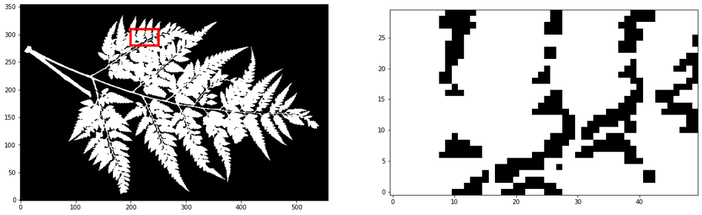

```python
leaf_file = '../example_data/leafbw.tif'

#If running from colab, uncomment the following line
#leaf_file = 'gdrive/My Drive/tda_workshop/example_data/leafbw.tif'

leaf_img = tf.imread(leaf_file)
leaf_img[leaf_img > 0] = 1

fig, ax = plt.subplots(1,2,figsize=(20,6))
ax[0].imshow(leaf_img.T, cmap='gray', origin='lower');
ax[0].plot([200,200,250,250,200], [280,310,310,280,280], c='red', lw=4);
ax[1].imshow(leaf_img.T[280:310, 200:250], cmap='gray', origin='lower');
```

# Step 2: Complexify the image

- We'll work with the dual cubical complex: the pixels will be treated as vertices.
- This complex corresponds to the 4-neighbor 2D digital topology.

[figure not shown]

$$\begin{align} \chi &= 20 \;\mathrm{ vertices } - 22 \;\mathrm{edges} + 3 \;\mathrm{faces}\\ &= 2\;\mathrm{connected\; components} - 1\;\mathrm{loop} + 0\;\mathrm{voids} \end{align} $$

- The code works in linear time with respect to the number of image pixels/voxels

```python
for i in range(len(leaf.cells)):
    print('{}-dim cells summarized in a {} numpy.array'.format(i, leaf.cells[i].shape))
    for j in range(6):
        print(j, '\t', leaf.cells[i][j,:])
    print('---')
```

```
0-dim cells summarized in a (53832, 2) numpy.array
0 	 [  8 269]
1 	 [  8 270]
2 	 [  9 268]
3 	 [  9 269]
4 	 [  9 270]
5 	 [  9 271]
---
1-dim cells summarized in a (99196, 2) numpy.array
0 	 [0 1]
1 	 [0 3]
2 	 [1 4]
3 	 [2 3]
4 	 [2 7]
5 	 [3 4]
---
2-dim cells summarized in a (45167, 4) numpy.array
0 	 [0 1 3 4]
1 	 [2 3 7 8]
2 	 [3 4 8 9]
3 	 [ 4  5  9 10]
4 	 [ 5  6 10 11]
5 	 [ 7  8 14 15]
---
```

# Step 3: Choose directions

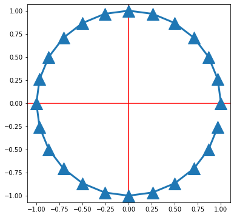

```python
circle_dirs = dirs.regular_directions(24, dims=leaf.ndim)
plt.figure(figsize=(6,6))
plt.axhline(0, color='red')
plt.axvline(0, color='red')
plt.plot(circle_dirs[:,0], circle_dirs[:,1], marker='^', ms=20, lw=3)
plt.axis('equal');
```

# Step 4: Compute the Euler Characteristic Curve (ECC) along one direction

```python
## Plot functions so that we do not clutter the next slides/cells

def plot_ecc(CComplex, filtration, T, title='title', ylim=(-30,30)):
    fig, ax = plt.subplots(2,3, figsize=(15,6), facecolor='snow')
    fig.suptitle('ECC for filter: {}'.format(title), fontsize=30)
    for j in range(2):
        for k in range(3):
            ax[j,k].plot((0,0),ylim, c='white')
            ax[j,k].set_ylabel('Euler characteristic', fontsize=12)
            ax[j,k].set_xlabel('Sublevel set', fontsize=12)
            ax[j,k].plot(CComplex.ECC(filtration, T[3*j+k]),
                         lw=3, label = 'T = {}'.format(T[3*j+k]))
            ax[j,k].legend(fontsize=14)
            ax[j,k].set_facecolor('gainsboro')
    fig.tight_layout()

def plot_ecc_filtration(CComplex, filtration, T, TT=32, title='title', ydot=(-30,30), direction=None):
    bins = np.linspace(np.min(filtration), np.max(filtration), TT+1)
    indices = np.digitize(filtration, bins=bins, right=False)

    fig = plt.figure(constrained_layout=True, figsize=(20,7), facecolor='snow')
    gs = fig.add_gridspec(2,4)
    for j in range(2):
        for k in range(2):
            ax = fig.add_subplot(gs[j,k])
            ax.plot((0,0),ydot, c='white')
            ax.set_ylabel('Euler characteristic', fontsize=12)
            ax.set_xlabel('Sublevel set', fontsize=12)
            ax.plot(CComplex.ECC(filtration, T[2*j+k]), lw=5, label = 'T = {}'.format(T[2*j+k]))
            ax.legend(fontsize=20)
            ax.set_facecolor('gainsboro')
    ax = fig.add_subplot(gs[:,2:])
    scatter = ax.scatter(*CComplex.cells[0].T,
                         s=0.2, c=indices, cmap='plasma', label='T = {}'.format(TT))
    ax.set_facecolor('whitesmoke')
    if direction is not None:
        start = 0.5*(np.max(CComplex.cells[0], axis=0) + np.min(CComplex.cells[0], axis=0))
        norm = 0.5*np.linalg.norm(start-np.max(leaf.cells[0], axis=0))
        #start += 0.5*norm*direction
        end = norm*direction
        ax.arrow(*start, *end, head_width=30, head_length=20, width=4, color='blue')

    ax.legend(fontsize=20, markerscale=30)
    cbar = plt.colorbar(scatter, ax=ax, orientation='horizontal', pad=0.01);
    ax.axis('equal');
    cbar.ax.tick_params(labelsize=20)

    fig.suptitle('ECC for filter: {}'.format(title), fontsize=30);
```

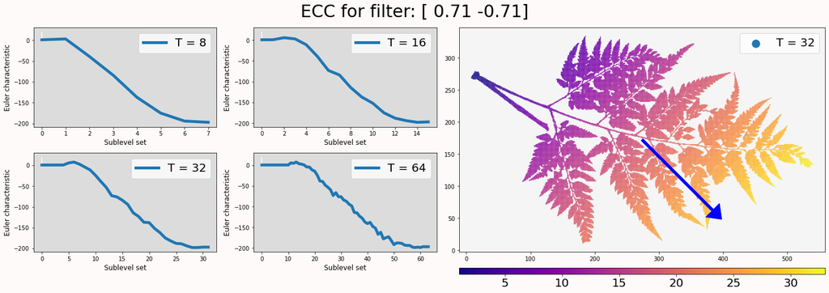

```python
T = [8,16,32,64,128]
i = 21
direction = circle_dirs[i, :]
heights = np.sum(leaf.cells[0]*direction, axis=1)
plot_ecc_filtration(leaf, heights, T, title=np.around(direction,2), ydot=(1,20), direction=direction)
```

# Step 5: Concatenate to get the Euler Characteristic Transform (ECT)

```
Complex with 53832 vertices

ECT with 24 directions in 0.1567 seconds.
0.0065s per direction
```

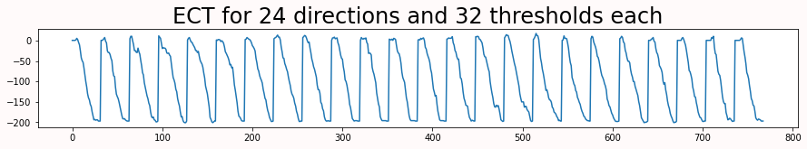

```python
t = 32
tic = time.perf_counter()
ect = leaf.ECT(circle_dirs, T=t)
toc = time.perf_counter()
print("Complex with {} vertices\n".format(len(leaf.cells[0])))
print("ECT with {} directions in {:.4f} seconds.\n{:.4f}s per direction".format(len(circle_dirs), toc-tic, (toc-tic)/len(circle_dirs)))

plt.figure(figsize=(15,2), facecolor='snow')
plt.plot(ect);
plt.title('ECT for {} directions and {} thresholds each'.format(len(circle_dirs),t), fontsize=24);
```

# Same run with 3D data

[figure not shown]

```python
seed_file = '../example_data/seed_8_0_p7_d4_t120_o7_e1_g3.tif'

#If running from colab, uncomment the following line
#leaf_file = 'gdrive/My Drive/tda_workshop/example_data/seed_8_0_p7_d4_t120_o7_e1_g3.tif'

seed_img = tf.imread(seed_file)
seed_img[seed_img > 0] = 1

tic = time.perf_counter()
seed = euler.CubicalComplex(seed_img).complexify()
toc = time.perf_counter()

print("Complexify in {:.4f} seconds.\n\nCubical complex made of:".format(toc-tic))
seed.summary();
```

```
Complexify in 2.2297 seconds.

Cubical complex made of:
53631	vertices
154741	edges
148746	squares
47635	cubes
----
Euler Characteristic: 1
```

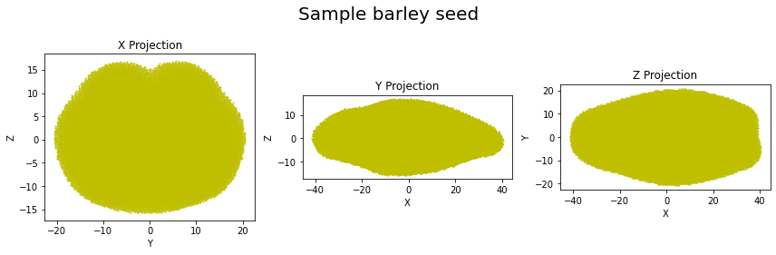

```python
max_vox = misc.find_tip(seed.cells[0], 2,1,0)
seed_coords,_, _, _,_ = misc.rotateSVD(seed.cells[0], max_vox)

misc.plot_3Dprojections(seed_coords, 'Sample barley seed')
```

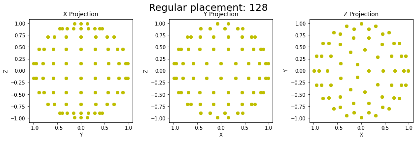

```python
sphere_dirs = dirs.regular_directions(128)
title = 'Regular placement: {}'.format(len(sphere_dirs))
misc.plot_3Dprojections(sphere_dirs, title, markersize=12)
```

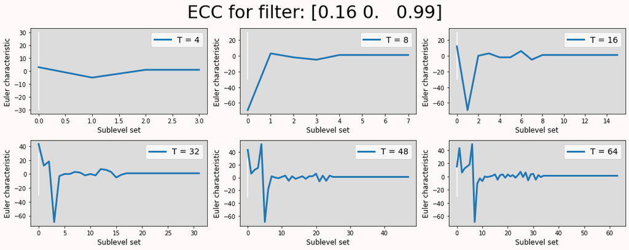

```python
T = [4,8,16,32,48,64]
i = 0
direction = sphere_dirs[i,:]
heights = np.sum(seed_coords*direction, axis=1)

plot_ecc(seed, heights, T, title=np.around(direction,2))
```

```
Complex with 53631 vertices

ECT with 128 directions in 2.0780 seconds.
0.0162s per direction
```

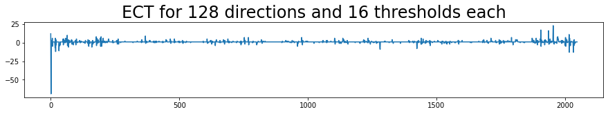

```python
t = 16
tic = time.perf_counter()
ect = seed.ECT(sphere_dirs, T=t, verts=seed_coords)
toc = time.perf_counter()
print("Complex with {} vertices\n".format(len(seed_coords)))
print("ECT with {} directions in {:.4f} seconds.\n{:.4f}s per direction".format(len(sphere_dirs), toc-tic, (toc-tic)/len(sphere_dirs)))

plt.figure(figsize=(15,2))
plt.plot(ect);
plt.title('ECT for {} directions and {} thresholds each'.format(len(sphere_dirs),t), fontsize=24);
```

# Not limited to just directional filters

```
Shaped series: series shape does not match page shape
```

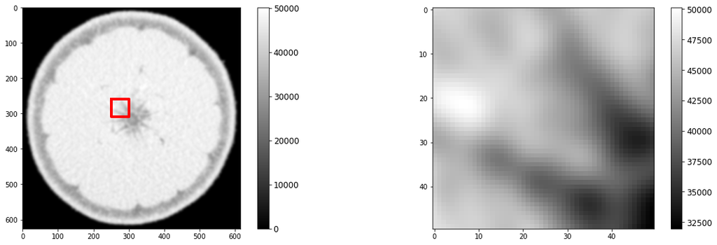

```python
orange_file = '../example_data/orange_blur.tif'

#If running from colab, uncomment the following line
#leaf_file = 'gdrive/My Drive/tda_workshop/example_data/orange_blur.tif'

orange_img = tf.imread(orange_file)

fig, ax = plt.subplots(1,2,figsize=(20,6))
show = ax[0].imshow(orange_img, cmap='gray');
cbar = plt.colorbar(show, ax=ax[0])
cbar.ax.tick_params(labelsize=12)
ax[0].plot([250,250,300,300,250], [260,310,310,260,260], c='red', lw=4)
show = ax[1].imshow(orange_img[260:310, 250:300], cmap='gray');
cbar = plt.colorbar(show, ax=ax[1], orientation='vertical');
cbar.ax.tick_params(labelsize=12);
```

```python
tic = time.perf_counter()
orange = euler.CubicalComplex(orange_img).complexify()
toc = time.perf_counter()

print("Complexify in {:.4f} seconds.\n\nCubical complex made of:".format(toc-tic))
orange.summary();
```

```
Complexify in 6.9966 seconds.

Cubical complex made of:
303323	vertices
605401	edges
302079	squares
----
Euler Characteristic: 1
```

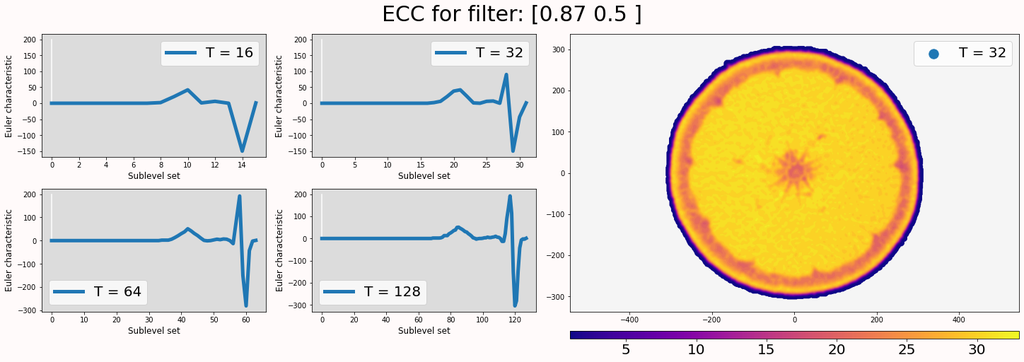

```python
T = [16, 32, 64, 128, 256, 512]
i = 2
direction = circle_dirs[i, :]
heights = np.sum(orange.cells[0]*direction, axis=1)
heights = orange.img[orange.img > 0]
title=np.around(direction,2)

#ylim = (0,3)
ylim = (0,200)
plot_ecc_filtration(orange, heights, T, title=title, ydot=ylim)
```

## Even more filters

```python
def radial_distance(coords):
    return np.sqrt(np.sum(coords**2, axis=1))
def distance_transform(img):
    dtc = ndimage.distance_transform_cdt(img, metric='taxicab')
    return dtc[img > 0]
```

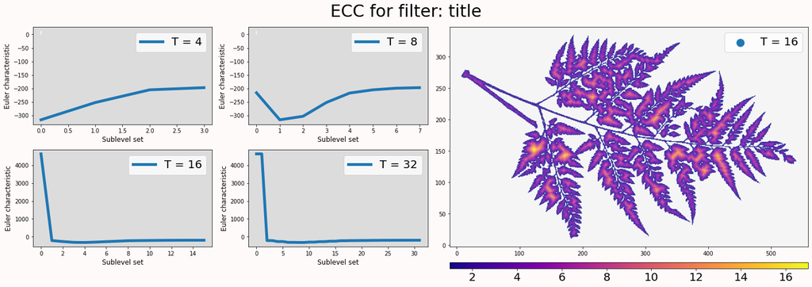

```python
T = [4,8,16,32]
filtration = radial_distance(leaf.cells[0])
ylim = (0,12)
#T = [4,8,16,32]
filtration = distance_transform(leaf.img)
#ylim = (-10,15)

plot_ecc_filtration(leaf, filtration, T, TT=16, ydot=ylim)
```

# What next?

## Go crazy!

- Experiment with different number of directions
- And different ways to define directions
- What other filter functions can you think of?

# Thank you!

- Joint work with [Dan Chitwood](https://dhchitwood.wixsite.com/morphologylab/publications) and [Liz Munch](http://www.elizabethmunch.com/) at CMSE/Horticulture/Math @ Michigan State University
- Image processing/computational tips from [Tim Ophelders](https://www.win.tue.nl/~tophelde/)
- X-ray CT scans done by [Michelle Quigley](https://www.canr.msu.edu/people/michelle-quigley)
- Barley seeds provided by [Dan Koenig](https://koeniglab.com/) and [Jacob Landis](https://jacoblandis.com/)
- Citrus provided by [Danelle Seymour](https://www.seymour-lab.com/)
- Fern leaf 2D scan courtesy of [Rebecca Dikow](https://datascience.si.edu/people/dr-rebecca-dikow) and [Alexander White](http://www.alexwhitebiology.com/).

| amezqui3@msu.edu | egr.msu.edu/~amezqui3 |  |  |
| --- | --- | --- | --- |